# Azure Test Drive

[[edit on GitHub]](https://github.com/chef/chef-web-docs/blob/main/content/azure_testdrive.md)

Chef Automate is an enterprise platform that allows developers, operations, and security engineers to collaborate on application and infrastructure changes with speed and at scale. Chef Automate provides actionable insights across data centers and cloud providers, wherever your nodes live.

Chef Automate is the center of the modern Chef platform, providing users with a single source of truth for infrastructure, security, and application automation. The comprehensive dashboard provides real-time views of your configuration management activity. Chef Automate comes bundled with the latest Chef Infra Server, providing the core tools you need to manage your enterprise infrastructure. Data collection is enabled by default, allowing your nodes to report activity in real-time. This instance is free for 60 days or you can bring your own license (BYOL).

Use this instance with Chef Workstation installed on your laptop or a separate Azure instance.

Chef Workstation includes:

- Chef Infra Client
- Chef InSpec
- Chef Habitat
- `chef` and `knife` command line tools
- Testing tools, such as Test Kitchen and Cookstyle
- Everything else needed to author cookbooks and upload them to the Chef Infra Server.

If you need to run Automate with a high availability (HA) topology, please contact [Chef Support](https://www.chef.io/support).

## Test Drive

A **Test Drive** is a ready-to-go environment that allows you to experience Chef Automate for free, without an Azure subscription (You will need a [Microsoft account](https://signup.live.com/). The Test Drive comes already provisioned—you don’t need to download, set up, or configure it—instead, you can spend two hours evaluating the user experience, key features, and benefits of the product.

### Get Started

1. Navigate to Chef Automate on the [Azure Marketplace](https://azuremarketplace.microsoft.com/en-us/marketplace/apps/chef-software.chef-automate).

[figure not shown]

2. Select **Test Drive**.

[figure not shown]

3. Sign in with your Microsoft account email address.

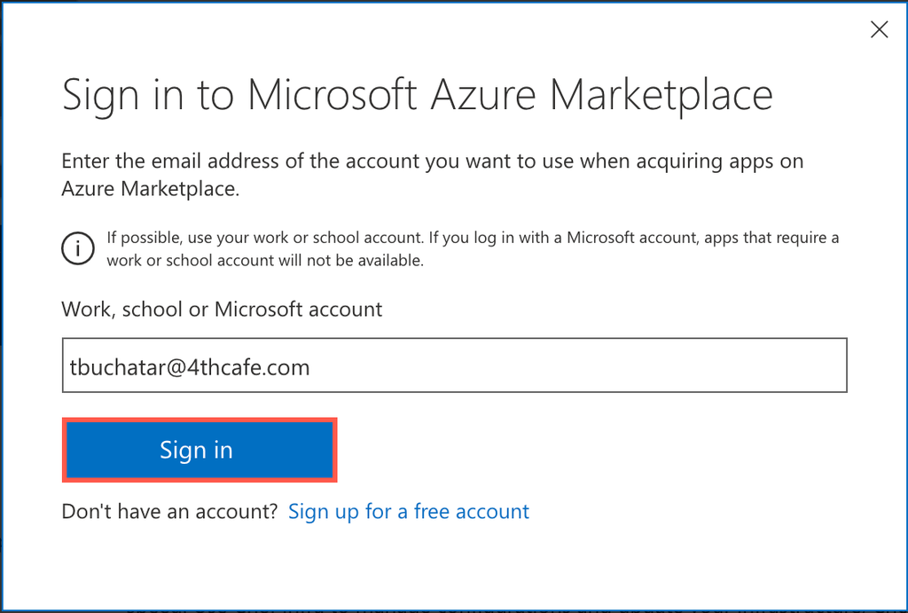

4. Enter your password and select **Sign In**.

[figure not shown]

5. Select **Continue** to accept the Microsoft information terms.

[figure not shown]

### Deploy Automate

1. Chef Automate deploys automatically. It takes about 15 minutes to finish.

[figure not shown]

2. Once Chef Automate deploys, you have **2 hours** to explore.

[figure not shown]

### Connect

1. Within 5 minutes of the Chef Automate deployment, you will receive an email with your username, password, and the URL for your deployment.

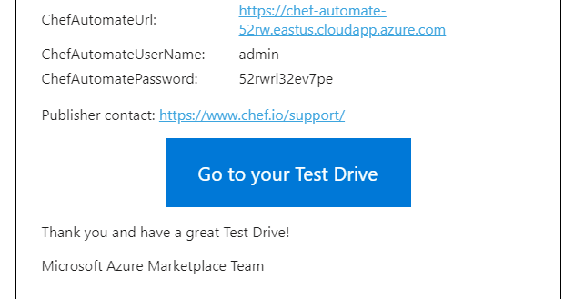

2. Open your browser and access the Chef Automate URL and select Advanced and continue as shown below

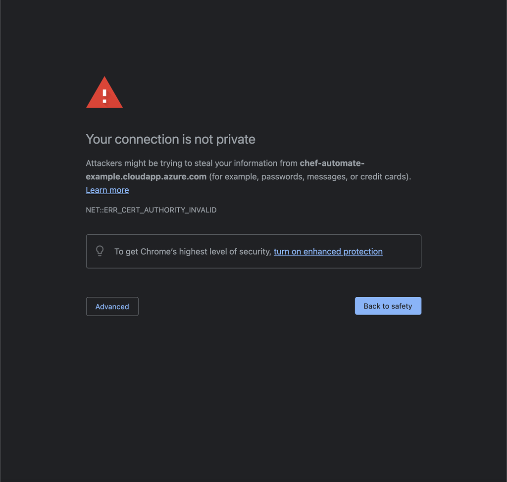

3. Enter your username, password from the email and select **Sign In** to Access Chef Automate

[figure not shown]

4. Enter your name and email address, accept the Chef license, and then select **Register**

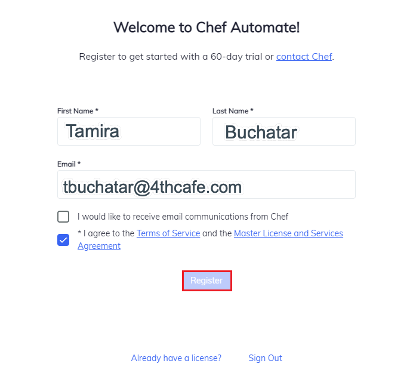

5. Congratulations! You’re ready to explore Chef Automate!

[figure not shown]